# Predicting Diabetes

Rahul Saini,Prateek sah,Rahul Pandey

6/27/2019

```r
knitr::opts_chunk$set(warning=FALSE, message=FALSE)

pagebreak <- function() {
    return('<div style="page-break-before: always;" />')
}
```

### *INTRODUCTION*

**Diabetes is a common chronic disease and poses a great threat to human health. The characteristic of diabetes is that the blood glucose is higher than the normal level, which is caused by defective insulin secretion or its impaired biological eﬀects, or both. According to the growing morbidity in recent years, in 2040, the world’s diabetic patients will reach 642 million, which means that one of the ten adults in the future is suffering from diabetes. There is no doubt that this alarming ﬁgure needsgreat attention.** **We used decisiontree,prune tree,random forest and logistic regression like machine learning techniques to predict diabetes.**

### **Reading the File**

```r
diab= read.csv("diabetes.csv", header=T, stringsAsFactors=F)
db = read.csv('diabetes.csv', header=TRUE)
diabetes1=db
```

### **DIMENSIONS OF DATASET**

Number of Observations and number of columns

```r
dim(db)
```

```
## [1] 768   9
```

### **PEEK AT THE DATA**

Name of the Columns in dataset.  
**Pregnancies:** Number of times pregnant  
**Glucose:** Plasma glucose concentration a 2 hours in an oral glucose tolerance test.  
**BloodPressure:** Diastolic blood pressure (mm Hg).  
**SkinThickness:** Triceps skin fold thickness (mm).  
**Insulin:** It is a hormone which regulates blood sugar level. 2-Hour serum insulin (mu U/ml)  
**BMI:** Body mass index (weight in kg/(height in m)^2).  
**DiabetesPedigreeFunction:** It provided some data on diabetes history in relatives of the patient.  
**Age:** It indiacates the age of person(Years) whose data was recorded.  
**Outcome:** Class variable (0 or 1)  
1 indicates that the person has diabetes  
0 indicates that the person doesn’t have diabetes.

```r
names(db)
```

```
## [1] "Pregnancies" "Glucose"     "BP"          "ST"          "Insulin"
## [6] "BMI"         "DPF"         "Age"         "Outcome"
```

**Structure of the dataset.**

```r
str(db)
```

```
## 'data.frame':    768 obs. of  9 variables:
##  $ Pregnancies: int  6 1 8 1 0 5 3 10 2 8 ...
##  $ Glucose    : int  148 85 183 89 137 116 78 115 197 125 ...
##  $ BP         : int  72 66 64 66 40 74 50 0 70 96 ...
##  $ ST         : int  35 29 0 23 35 0 32 0 45 0 ...
##  $ Insulin    : int  0 0 0 94 168 0 88 0 543 0 ...
##  $ BMI        : num  33.6 26.6 23.3 28.1 43.1 25.6 31 35.3 30.5 0 ...
##  $ DPF        : num  0.627 0.351 0.672 0.167 2.288 ...
##  $ Age        : int  50 31 32 21 33 30 26 29 53 54 ...
##  $ Outcome    : int  1 0 1 0 1 0 1 0 1 1 ...
```

**Showing the first 6 values in dataset using the Head function.**

```r
head(db)
```

```
##   Pregnancies Glucose BP ST Insulin  BMI   DPF Age Outcome
## 1           6     148 72 35       0 33.6 0.627  50       1
## 2           1      85 66 29       0 26.6 0.351  31       0
## 3           8     183 64  0       0 23.3 0.672  32       1
## 4           1      89 66 23      94 28.1 0.167  21       0
## 5           0     137 40 35     168 43.1 2.288  33       1
## 6           5     116 74  0       0 25.6 0.201  30       0
```

**Showing the last 6 values in dataset using the Tail function.**

```r
tail(db)
```

```
##     Pregnancies Glucose BP ST Insulin  BMI   DPF Age Outcome
## 763           9      89 62  0       0 22.5 0.142  33       0
## 764          10     101 76 48     180 32.9 0.171  63       0
## 765           2     122 70 27       0 36.8 0.340  27       0
## 766           5     121 72 23     112 26.2 0.245  30       0
## 767           1     126 60  0       0 30.1 0.349  47       1
## 768           1      93 70 31       0 30.4 0.315  23       0
```

**Correlation between Variables**

```r
cor(db[,1:7])
```

```
##             Pregnancies    Glucose         BP          ST     Insulin
## Pregnancies  1.00000000 0.12945867 0.14128198 -0.08167177 -0.07353461
## Glucose      0.12945867 1.00000000 0.15258959  0.05732789  0.33135711
## BP           0.14128198 0.15258959 1.00000000  0.20737054  0.08893338
## ST          -0.08167177 0.05732789 0.20737054  1.00000000  0.43678257
## Insulin     -0.07353461 0.33135711 0.08893338  0.43678257  1.00000000
## BMI          0.01768309 0.22107107 0.28180529  0.39257320  0.19785906
## DPF         -0.03352267 0.13733730 0.04126495  0.18392757  0.18507093
##                    BMI         DPF
## Pregnancies 0.01768309 -0.03352267
## Glucose     0.22107107  0.13733730
## BP          0.28180529  0.04126495
## ST          0.39257320  0.18392757
## Insulin     0.19785906  0.18507093
## BMI         1.00000000  0.14064695
## DPF         0.14064695  1.00000000
```

### **Column Manipulation**

OUtcome to factor  
1->Yes  
0->No

```r
diab$Outcome <- as.factor(diab$Outcome)
levels(diab$Outcome) <- c("No","Yes")
```

### **STATISTICAL SUMMARY**

```r
summary(db)
```

```
##   Pregnancies        Glucose            BP               ST
##  Min.   : 0.000   Min.   :  0.0   Min.   :  0.00   Min.   : 0.00
##  1st Qu.: 1.000   1st Qu.: 99.0   1st Qu.: 62.00   1st Qu.: 0.00
##  Median : 3.000   Median :117.0   Median : 72.00   Median :23.00
##  Mean   : 3.845   Mean   :120.9   Mean   : 69.11   Mean   :20.54
##  3rd Qu.: 6.000   3rd Qu.:140.2   3rd Qu.: 80.00   3rd Qu.:32.00
##  Max.   :17.000   Max.   :199.0   Max.   :122.00   Max.   :99.00
##     Insulin           BMI             DPF              Age
##  Min.   :  0.0   Min.   : 0.00   Min.   :0.0780   Min.   :21.00
##  1st Qu.:  0.0   1st Qu.:27.30   1st Qu.:0.2437   1st Qu.:24.00
##  Median : 30.5   Median :32.00   Median :0.3725   Median :29.00
##  Mean   : 79.8   Mean   :31.99   Mean   :0.4719   Mean   :33.24
##  3rd Qu.:127.2   3rd Qu.:36.60   3rd Qu.:0.6262   3rd Qu.:41.00
##  Max.   :846.0   Max.   :67.10   Max.   :2.4200   Max.   :81.00
##     Outcome
##  Min.   :0.000
##  1st Qu.:0.000
##  Median :0.000
##  Mean   :0.349
##  3rd Qu.:1.000
##  Max.   :1.000
```

### **VISUALIZE DATASET**

**We compute the matrix of CORRELATION between the variables.**

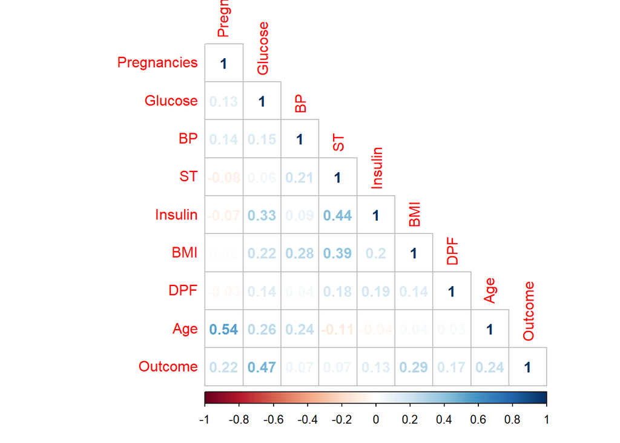

```r
library(corrplot)
corrplot(cor(db), type = "lower", method = "number")
```

### Histogram

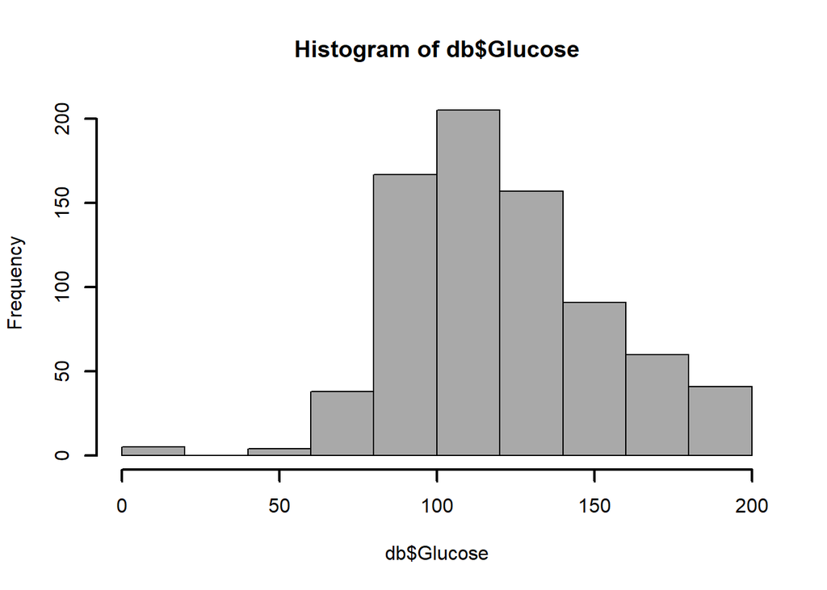

```r
hist(db$Glucose,col="darkgray",lwd=2)
```

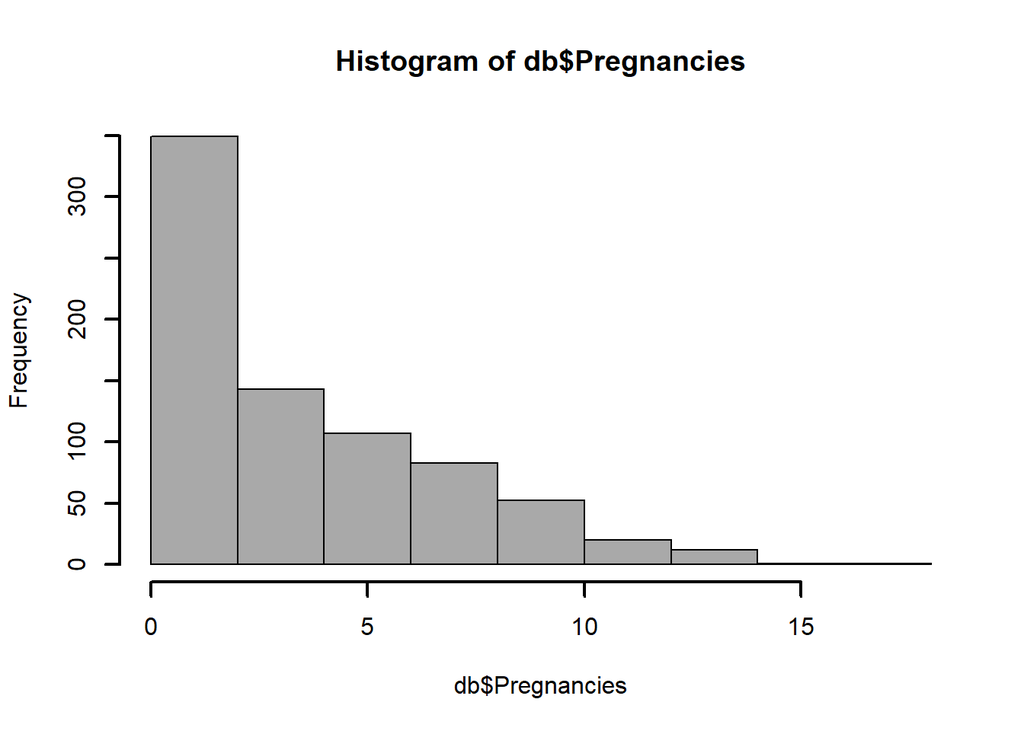

```r
hist(db$Pregnancies,col="darkgray",lwd=2)
```

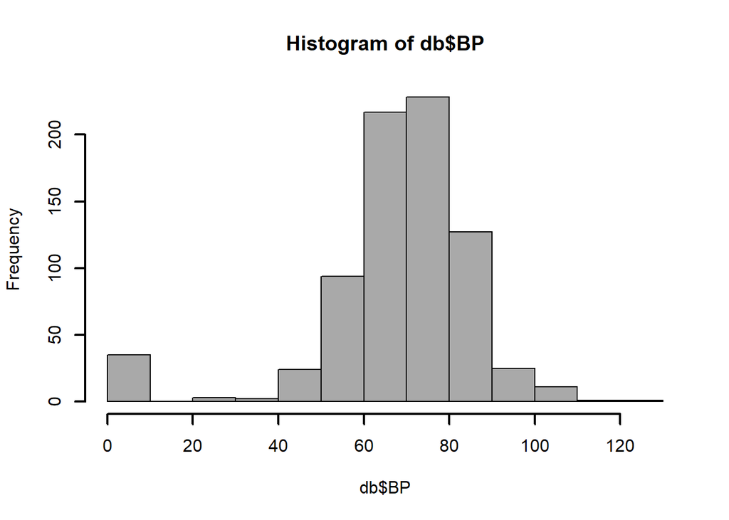

```r
hist(db$BP,col="darkgray",lwd=2)
```

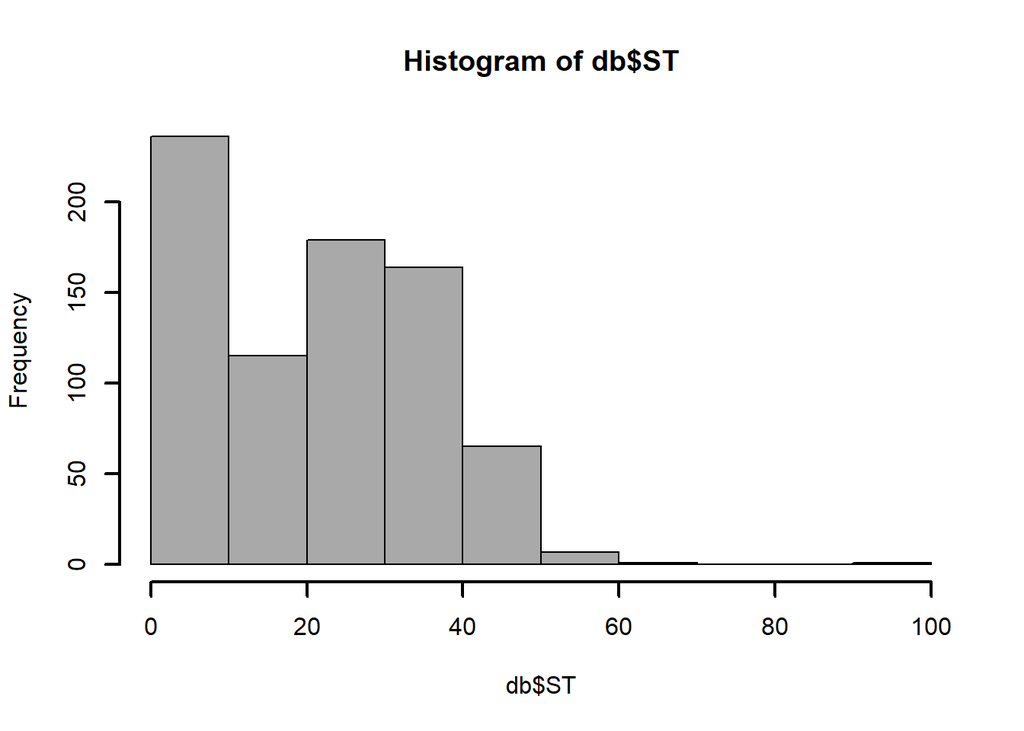

```r
hist(db$ST,col="darkgray",lwd=2)
```

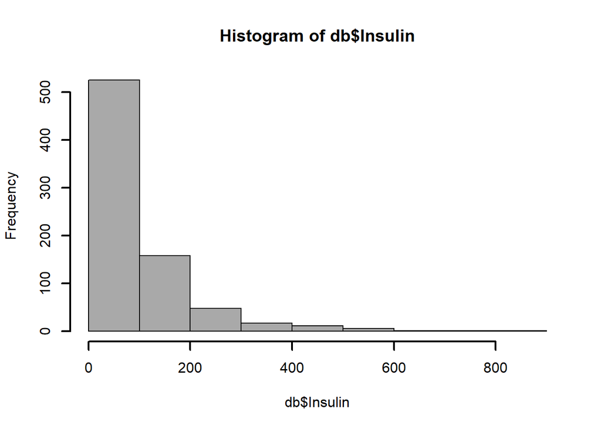

```r
hist(db$Insulin,col="darkgray",lwd=2)
```

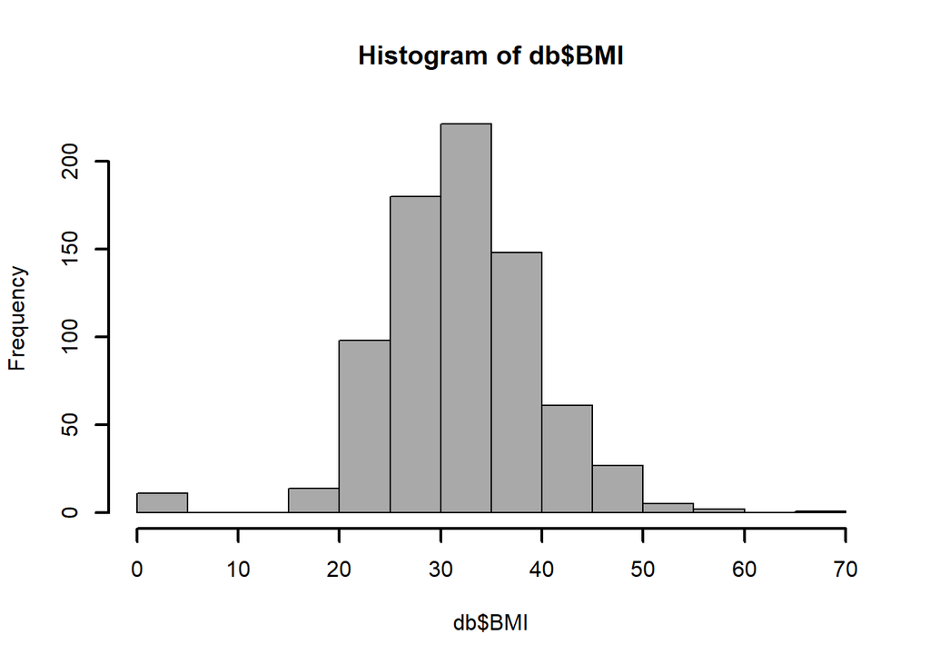

```r
hist(db$BMI,col="darkgray",lwd=2)
```

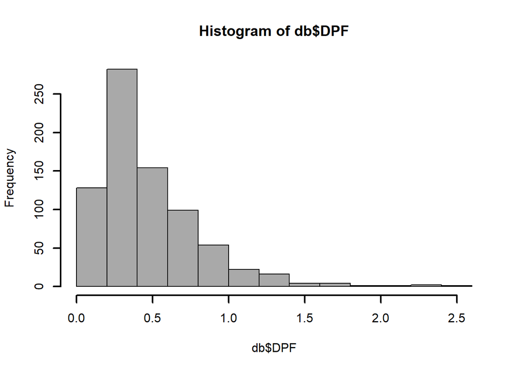

```r
hist(db$DPF,col="darkgray",lwd=2)
```

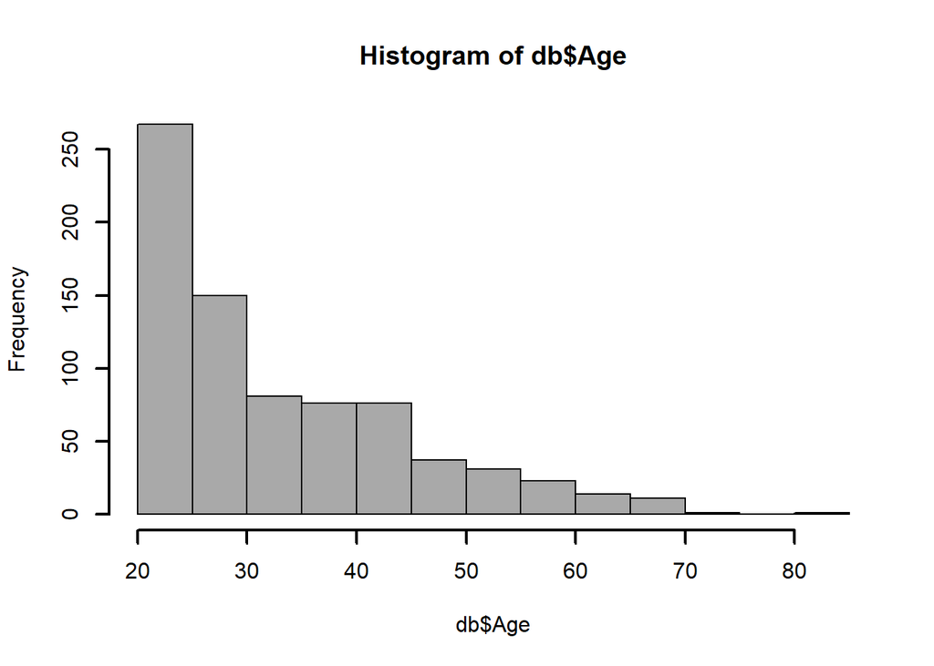

```r
hist(db$Age,col="darkgray",lwd=2)
```

### **Creating train and test data**

```r
nrows <- NROW(diab)
set.seed(69)                            # fix random value
index <- sample(1:nrows, 0.75 * nrows)  # shuffle and divide
# train <- diab                         # 768 test data (100%)
train <- diab[index,]                   # 576 test data (75%)
test <- diab[-index,]                   # 192 test data (25%)
```

### **Initial values**

```r
prop.table(table(train$Outcome))
```

```
##
##        No       Yes
## 0.6440972 0.3559028
```

### **1.DECISION TREE**

*Now we present the Decision Trees algorithm*

```r
library(caret)
library(rpart)
learn_rp <- rpart(Outcome~.,data=train,control=rpart.control(minsplit=2))
pre_rp <- predict(learn_rp, test[,-9], type="class")
cm_rp  <- confusionMatrix(pre_rp, test$Outcome)
summary(cm_rp)
```

```
##          Length Class  Mode
## positive  1     -none- character
## table     4     table  numeric
## overall   7     -none- numeric
## byClass  11     -none- numeric
## mode      1     -none- character
## dots      0     -none- list
```

```r
learn_rp
```

```
## n= 576
##
## node), split, n, loss, yval, (yprob)
##       * denotes terminal node
##
##   1) root 576 205 No (0.64409722 0.35590278)
##     2) Glucose< 127.5 360  73 No (0.79722222 0.20277778)
##       4) Age< 28.5 198  16 No (0.91919192 0.08080808) *
##       5) Age>=28.5 162  57 No (0.64814815 0.35185185)
##        10) BMI< 26.35 30   1 No (0.96666667 0.03333333) *
##        11) BMI>=26.35 132  56 No (0.57575758 0.42424242)
##          22) DPF< 0.625 99  33 No (0.66666667 0.33333333)
##            44) Glucose< 93.5 24   2 No (0.91666667 0.08333333) *
##            45) Glucose>=93.5 75  31 No (0.58666667 0.41333333)
##              90) BMI>=34.65 32   8 No (0.75000000 0.25000000) *
##              91) BMI< 34.65 43  20 Yes (0.46511628 0.53488372)
##               182) BP>=83 6   1 No (0.83333333 0.16666667) *
##               183) BP< 83 37  15 Yes (0.40540541 0.59459459)
##                 366) Insulin>=11 10   3 No (0.70000000 0.30000000) *
##                 367) Insulin< 11 27   8 Yes (0.29629630 0.70370370) *
##          23) DPF>=0.625 33  10 Yes (0.30303030 0.69696970) *
##     3) Glucose>=127.5 216  84 Yes (0.38888889 0.61111111)
##       6) BMI< 29.85 56  16 No (0.71428571 0.28571429)
##        12) Glucose< 164 45   9 No (0.80000000 0.20000000) *
##        13) Glucose>=164 11   4 Yes (0.36363636 0.63636364) *
##       7) BMI>=29.85 160  44 Yes (0.27500000 0.72500000)
##        14) Glucose< 154.5 83  33 Yes (0.39759036 0.60240964)
##          28) Age< 30.5 40  17 No (0.57500000 0.42500000)
##            56) BP>=61 32   9 No (0.71875000 0.28125000) *
##            57) BP< 61 8   0 Yes (0.00000000 1.00000000) *
##          29) Age>=30.5 43  10 Yes (0.23255814 0.76744186) *
##        15) Glucose>=154.5 77  11 Yes (0.14285714 0.85714286) *
```

*Now we plot of the tree, and interpret the results.*

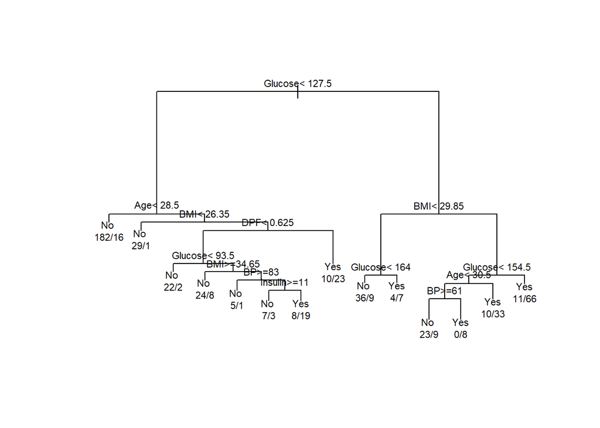

```r
plot(learn_rp, margin = 0.05); text(learn_rp, use.n = TRUE, cex = 0.7)
```

**“Diabetes” appears to be Glucose, since the first branch split criterion (e.g. Glucose < 127.5).** **Predict the response on the test data, and produce a confusion matrix comparing the test labels to the predicted test labels.**

**Test error rate**

```r
confusionMatrix(pre_rp, test$Outcome)
```

```
## Confusion Matrix and Statistics
##
##           Reference
## Prediction  No Yes
##        No  105  22
##        Yes  24  41
##
##                Accuracy : 0.7604
##                  95% CI : (0.6937, 0.8189)
##     No Information Rate : 0.6719
##     P-Value [Acc > NIR] : 0.00474
##
##                   Kappa : 0.461
##
##  Mcnemar's Test P-Value : 0.88278
##
##             Sensitivity : 0.8140
##             Specificity : 0.6508
##          Pos Pred Value : 0.8268
##          Neg Pred Value : 0.6308
##              Prevalence : 0.6719
##          Detection Rate : 0.5469
##    Detection Prevalence : 0.6615
##       Balanced Accuracy : 0.7324
##
##        'Positive' Class : No
##
```

**The test error rate is 23.96%. In other words, the accuracy is 76.04%.**

### **2.PRUNE TREE**

```r
learn_pru <- prune(learn_rp, cp=learn_rp$cptable[which.min(learn_rp$cptable[,"xerror"]),"CP"])
pre_pru <- predict(learn_pru, test[,-9], type="class")
cm_pru <-confusionMatrix(pre_pru, test$Outcome)
cm_pru
```

```
## Confusion Matrix and Statistics
##
##           Reference
## Prediction  No Yes
##        No  118  32
##        Yes  11  31
##
##                Accuracy : 0.776
##                  95% CI : (0.7104, 0.8329)
##     No Information Rate : 0.6719
##     P-Value [Acc > NIR] : 0.001015
##
##                   Kappa : 0.4447
##
##  Mcnemar's Test P-Value : 0.002289
##
##             Sensitivity : 0.9147
##             Specificity : 0.4921
##          Pos Pred Value : 0.7867
##          Neg Pred Value : 0.7381
##              Prevalence : 0.6719
##          Detection Rate : 0.6146
##    Detection Prevalence : 0.7812
##       Balanced Accuracy : 0.7034
##
##        'Positive' Class : No
##
```

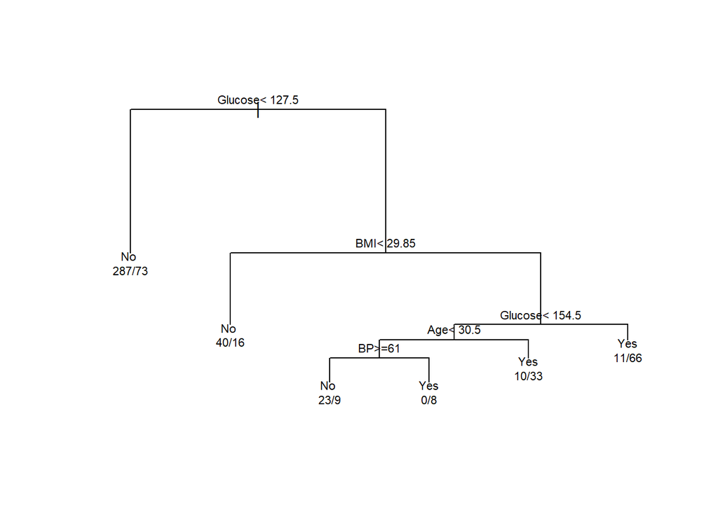

```r
plot(learn_pru, margin = 0.05); text(learn_pru, use.n = TRUE, cex = 0.7)
```